# QM 2022 Week 3: Statistical Inference

Oliver Rittmann Domantas Undzėnas Lion Behrens

September 21 | 22 | 23, 2022

# Today we will learn

0. Leftover from last week: Central Limit Theorem
1. How to Construct Confidence Intervals
   1. Analytically
   2. Using Simulation
   3. Using Bootstrapping
2. What is the idea behind confidence intervals
3. How to Estimate Difference in Means

In other words, our goals are to:

- Really understand what “statistical inference” means
- Review how we can assess the uncertainty of the inferences we make
- Learn about simulations, bootstrapping and classical hypothesis testing (and it’s only the third session, we are making good progress!)

# 1 Leftover: The Central Limit Theorem

## 1.1 Central Limit Theorem

Finally, we want to better understand the central limit theorem. Let’s generate a random population:

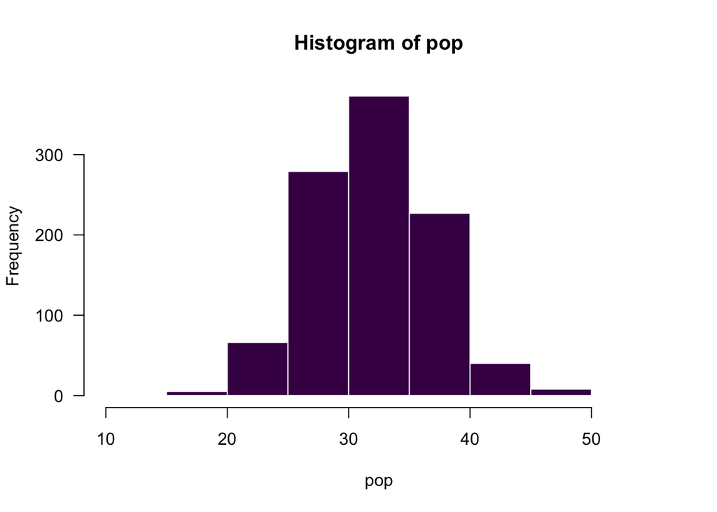

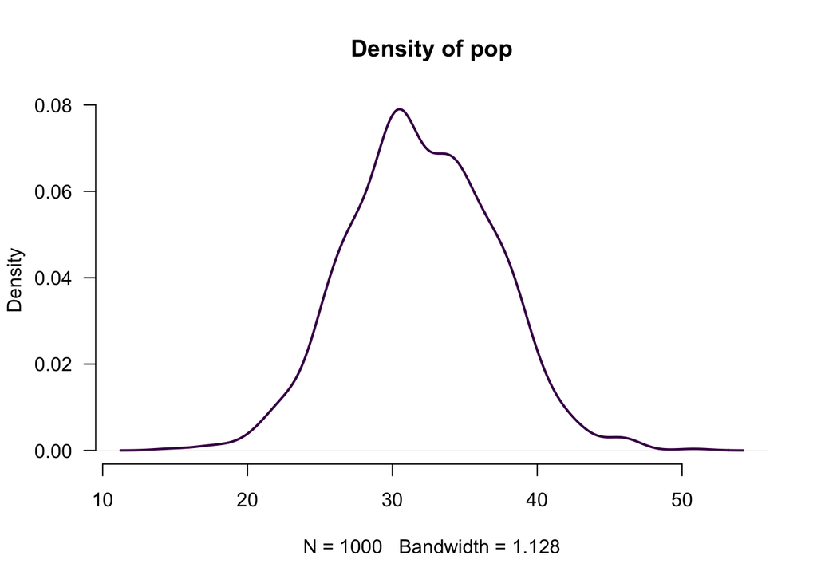

```r
pop <- rnorm(1000, mean = 32, sd = 5) # we know the "true" values
summary(pop)
##    Min. 1st Qu.  Median    Mean 3rd Qu.    Max.
##   14.62   28.63   31.75   32.01   35.42   50.83
var(pop)
## [1] 24.91205

hist(pop,
     bty = "n",
     las = 1,
     border = "white",
     col = viridis(1)
     )

plot(density(pop),
     bty = "n",
     las = 1,
     col = viridis(1),
     lwd = 2,
     main = "Density of pop"
     )

sample(pop, 200) # take a random sample of size 200 from the population
##   [1] 36.06138 32.44983 28.12770 31.05888 28.11468 34.53273 35.34717 32.26656
##   [9] 27.81997 25.67775 33.42948 38.47744 30.79277 31.43649 34.79590 31.73121
##  [17] 32.54177 37.89192 38.30703 34.82140 29.29629 35.22031 39.48547 34.04188
##  [25] 26.90496 45.46889 28.87182 33.15503 26.06899 36.64017 29.36656 36.02871
##  [33] 33.12095 38.45868 37.34821 30.39778 36.00969 36.89632 28.22961 30.30943
##  [41] 35.35534 38.57205 22.28083 34.81817 27.51257 30.62924 34.87799 28.95078
##  [49] 37.26577 30.52991 38.05316 29.09006 35.27206 30.78151 34.57119 33.32008
##  [57] 30.74649 44.24403 29.71973 34.42912 38.97987 34.35905 37.38339 34.36681
##  [65] 23.53752 27.25959 32.43618 36.59142 30.11357 45.74146 30.95080 36.82157
##  [73] 35.07479 25.54013 26.13327 30.91056 27.36353 22.60401 23.20850 24.77749
##  [81] 33.84426 38.83017 23.35593 41.46607 30.37802 31.82933 31.99636 31.62532
##  [89] 37.40095 35.25846 36.10059 32.77515 38.10272 26.72323 25.15086 30.77837
##  [97] 30.95370 27.66683 34.70771 25.40825 23.77036 29.96696 30.19811 31.92113
## [105] 34.18268 37.12349 27.12171 25.98166 35.84493 30.72330 31.61992 24.03972
## [113] 26.80760 32.74143 35.91297 29.44478 29.48699 30.46167 24.88534 38.63052
## [121] 38.73561 34.94878 35.80378 26.06990 35.06339 29.73227 24.79963 32.96334
## [129] 37.90951 37.10189 34.36512 42.14674 34.72028 32.84716 30.81664 37.22914
## [137] 42.64614 33.39753 27.70223 22.15344 25.53742 34.56283 36.89892 26.70267
## [145] 30.58295 36.03884 36.78123 33.54321 34.69648 31.73579 43.57249 39.49151
## [153] 28.19199 16.62499 34.26983 38.52330 27.90013 35.48942 23.08096 33.91826
## [161] 21.24642 38.36916 32.67890 38.22365 26.62796 28.62556 31.72137 17.49686
## [169] 33.56443 25.86323 37.10860 31.70453 39.13953 33.90458 23.18746 33.38977
## [177] 30.56447 28.34693 33.88237 31.05503 25.49518 33.80428 27.52100 33.20791
## [185] 36.06746 30.43931 31.13603 33.13044 36.29934 28.72958 39.48997 32.45532
## [193] 26.63298 35.88228 30.84680 38.78846 33.98379 42.88227 30.87433 34.90443
```

### 1.1.1 CLT Trial 1: Sample Size = 100

Let’s take 100 samples with 100 persons in each sample. First, we create an empty vector - `trial1` - of length 100 to store the results:

```r
trial1 <- rep(NA, 100)
```

Now we have to do some programming. We create a *for loop* counting $i$ from 1 to 100. For each iteration the loop is saving the mean of our sample in the vector `trial1`.

```r
for (i in 1:100){
  trial1[i] <- mean(sample(pop, 100))
}

trial1
##   [1] 32.62482 31.55643 32.30134 30.88074 31.73372 31.64481 31.29286 31.89355
##   [9] 32.39582 31.28209 31.18209 31.75551 32.07365 32.16808 32.10476 32.38981
##  [17] 31.65425 32.79278 31.95541 31.65746 31.52161 31.96045 31.63985 31.58933
##  [25] 32.15029 32.23692 31.94447 31.76420 31.87019 31.93128 31.57530 32.15200
##  [33] 31.41125 32.43435 31.17486 32.14795 32.80530 31.66177 31.84850 33.10893
##  [41] 31.96938 32.06508 31.62874 32.08850 32.18574 31.62344 31.81063 31.21614
##  [49] 31.62400 30.45758 31.68955 31.91862 32.24756 32.70464 31.85265 31.34860
##  [57] 31.97040 31.73794 32.05773 31.55467 31.91804 32.25716 32.50364 31.56753
##  [65] 31.96685 31.30615 33.07109 31.41671 32.46414 31.74113 31.81172 32.17937
##  [73] 31.30474 31.48642 31.53053 31.82708 32.21426 31.49567 31.97997 32.12901
##  [81] 32.13895 31.84704 32.91262 31.76672 31.85941 31.33433 32.76557 32.37357
##  [89] 31.89960 31.95407 32.56670 31.78016 31.11648 31.38068 32.05412 31.79868
##  [97] 30.87323 31.90469 31.94219 32.00672
```

Let’s have a look at our *sampling distribution*:

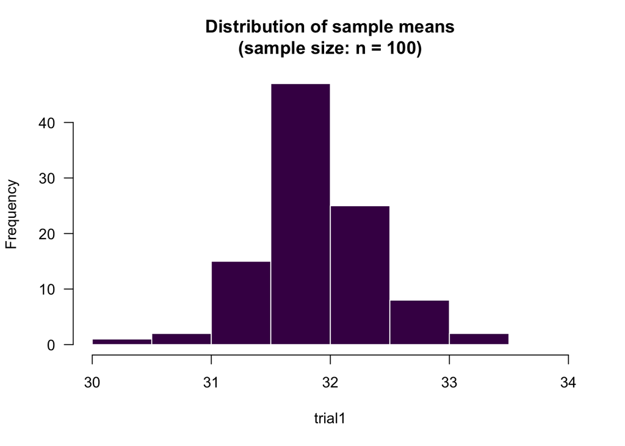

```r
hist(trial1,
     bty = "n",
     las = 1,
     border = "white",
     col = viridis(1),
     xlim = c(30, 34),
     main = "Distribution of sample means\n(sample size: n = 100)"
     )
```

```r
mean(trial1)
## [1] 31.88467
var(trial1)
## [1] 0.2215442
```

### 1.1.2 CLT Trial 2: Sample Size = 400

We do it again. But this time we will take 100 samples with 400 people in each sample. It works just as above.

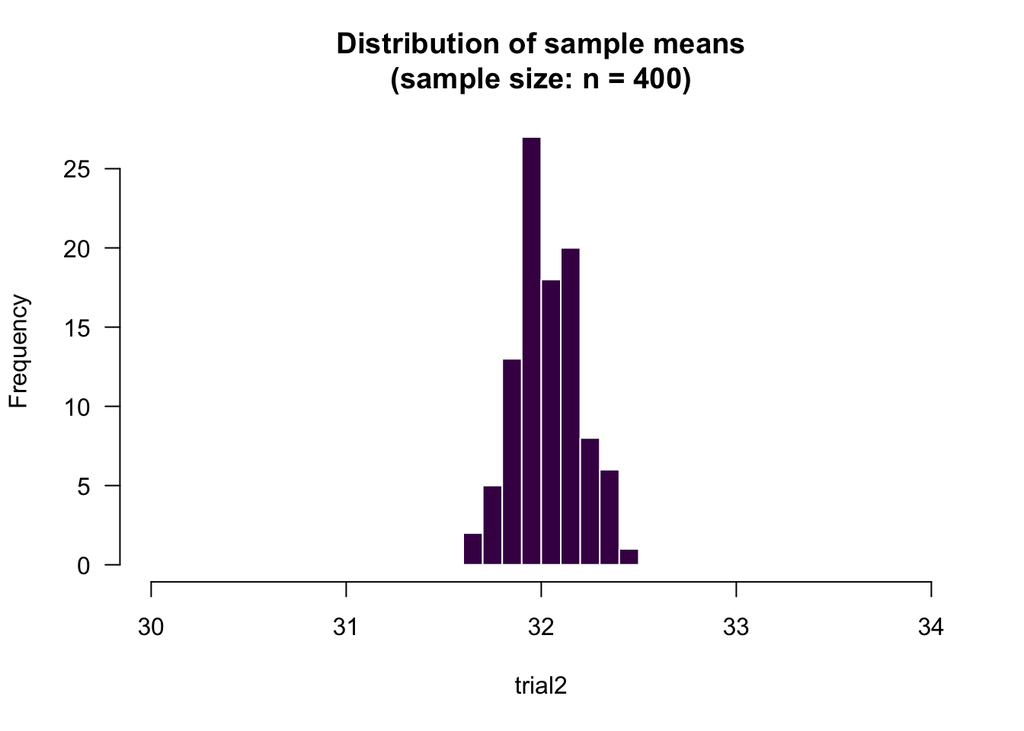

```r
trial2 <- rep(NA, 100)

for (i in 1:100){
  trial2[i] <- mean(sample(pop, 400))
}

hist(trial2,
     bty = "n",
     las = 1,
     border = "white",
     col = viridis(1),
     xlim = c(30, 34),
     main = "Distribution of sample means\n(sample size: n = 400)"
     )
```

```r
mean(trial2)
## [1] 32.03314
var(trial2)
## [1] 0.02765773
```

Does the variance of the sampling distribution behave according to $\frac{sd^2}{n}$?

The original standard deviation value was 5, so $\frac{25}{n}$ should be the variance of our sampling distribution!

```r
var(pop)/400
## [1] 0.06228014
```

In the lecture we learned that the sampling distribution of the mean always approaches a normal distribution, regardless of the shape of the original distribution!

You don’t believe me? See for yourself.

Income, for example, is usually not really normally distributed. First, we generate some hypothetical income data.

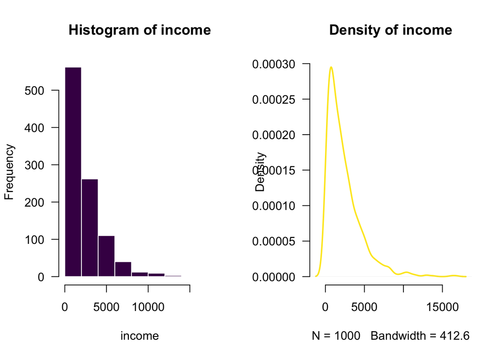

```r
income <- rgamma(1000, shape = 1.1, scale = 2000)
summary(income)
##      Min.   1st Qu.    Median      Mean   3rd Qu.      Max.
##     8.037   767.094  1759.971  2346.582  3212.971 16767.460
var(income)
## [1] 4840511

# Let's have a look.
par(mfrow = c(1, 2)) # two plots side-by-side (alternative to chunk arguments)
hist(income,
     bty = "n",
     las = 1,
     border = "white",
     col = viridis(2)[1]
     )

plot(density(income),
     bty = "n",
     las = 1,
     col = viridis(2)[2],
     lwd = 2,
     main = "Density of income"
     )
```

This is clearly a non-normal distribution. Now we want to get our sampling distribution of the mean again.

### 1.1.3 CLT Trial 3: A non-normal population distribution

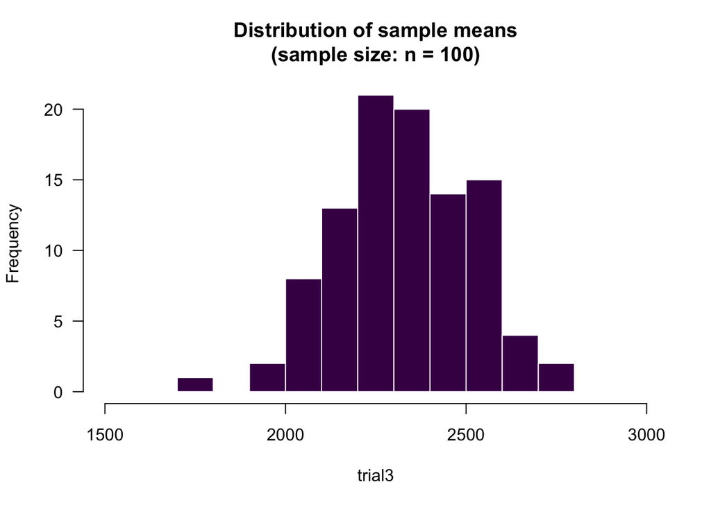

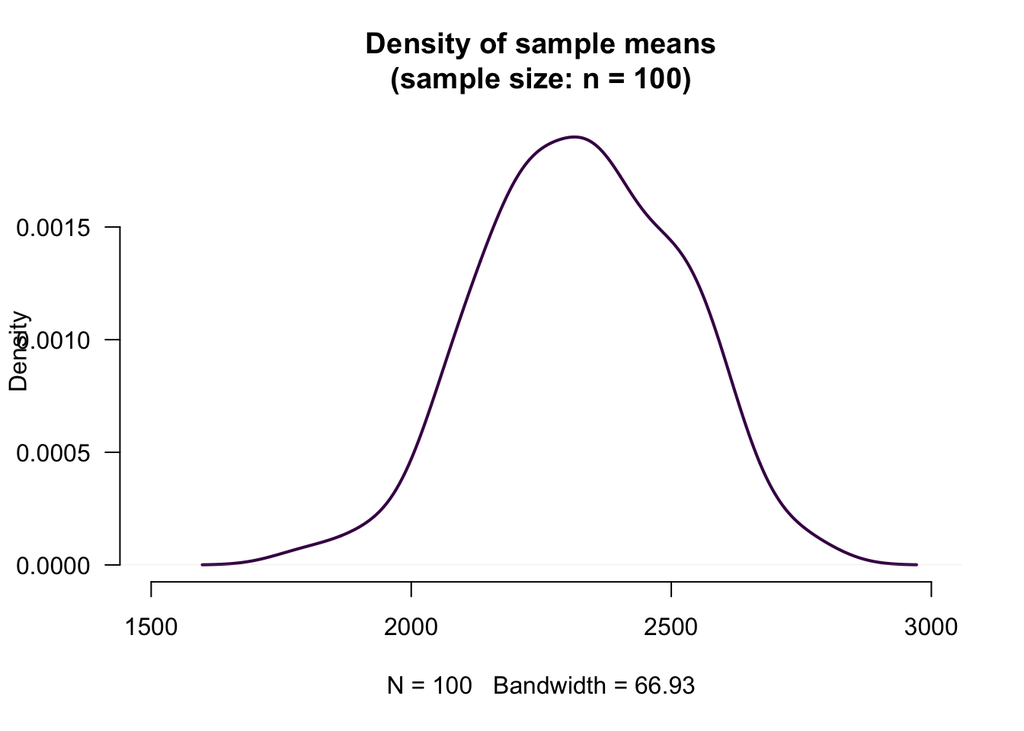

```r
trial3 <- rep(NA, 100)

for (i in 1:100){
  trial3[i] <- mean(sample(income, 100))
}

hist(trial3 ,
     bty = "n",
     las = 1,
     border = "white",
     col = viridis(1),
     xlim = c(1500, 3000),
     main = "Distribution of sample means\n(sample size: n = 100)"
     )

plot(density(trial3),
     bty = "n",
     las = 1,
     lwd = 2,
     col = viridis(1),
     xlim = c(1500, 3000),
     main = "Density of sample means\n(sample size: n = 100)"
     )

mean(trial3)
## [1] 2326.176
var(trial3)
## [1] 34893.56
```

### 1.1.4 CLT Trial 4: A non-normal population distribution II

#### 1.1.4.1 Base R

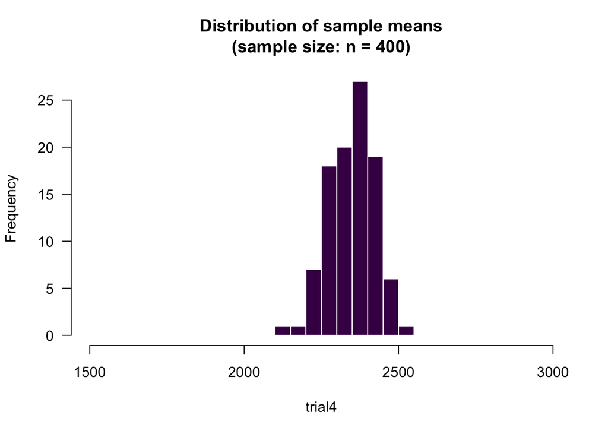

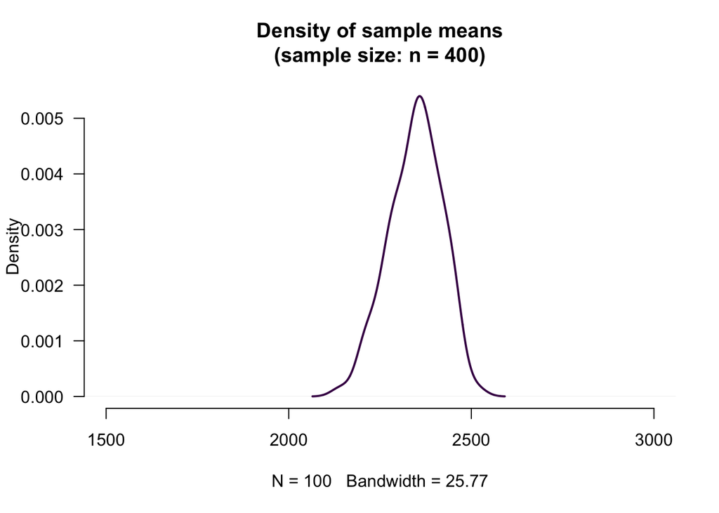

```r
trial4 <- rep(NA, 100)

for (i in 1:100){
  trial4[i] <- mean(sample(income, 400)) #this time, we sample 400 people
}

hist(trial4,
     bty = "n",
     las = 1,
     border = "white",
     col = viridis(1),
     xlim = c(1500, 3000),
     main = "Distribution of sample means\n(sample size: n = 400)"
     )

plot(density(trial4),
     bty = "n",
     las = 1,
     lwd = 2,
     col = viridis(1),
     xlim = c(1500, 3000),
     main = "Density of sample means\n(sample size: n = 400)"
     )

mean(trial4)
## [1] 2346.837
var(trial4)
## [1] 5174.035
```

#### 1.1.4.2 ggplot2

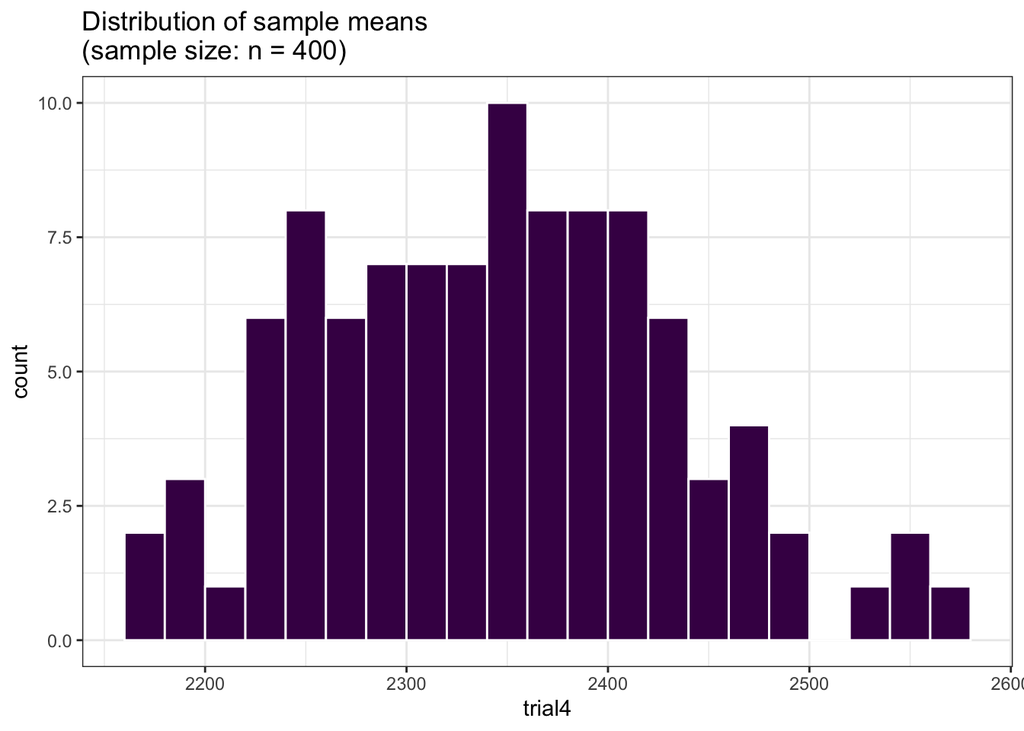

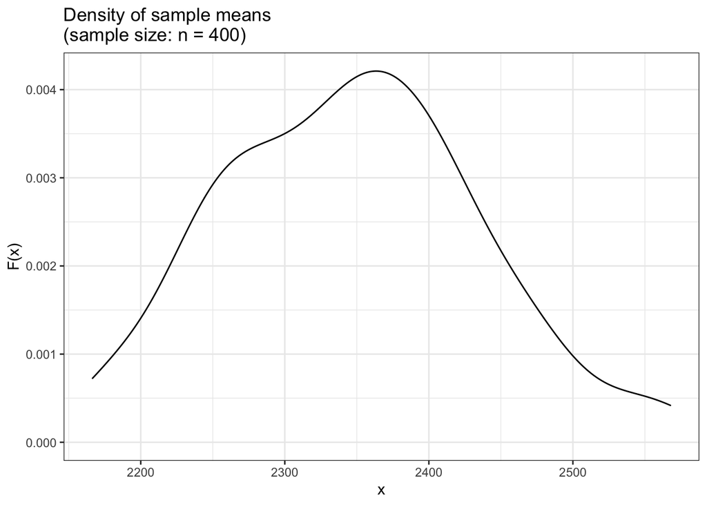

```r
trial4 <- rep(NA, 100)

for (i in 1:100){
  trial4[i] <- mean(sample(income, 400)) #this time, we sample 400 people
}

ggplot() +
  geom_histogram(aes(x = trial4),
                 boundary = 2200,
                 binwidth = 20,
                 color = "white",
                 fill = viridis(1)) +
  theme_bw() +
  labs(title = "Distribution of sample means\n(sample size: n = 400)")

ggplot() +
 geom_density(aes(trial4)) +
  labs(title = "Density of sample means\n(sample size: n = 400)",
       y = "F(x)",
       x = "x") +
  theme_bw()

mean(trial4)
## [1] 2345.988
var(trial4)
## [1] 7779.806
```

With today’s repository you downloaded the `.Rmd` script and the two datasets `support.RData` and `polity.dta`. They are in the folder `raw-data`. You can see them in the **Files** window.

# 2 Constructing Confidence Intervals (CIs)

## 2.1 Theory Refresher

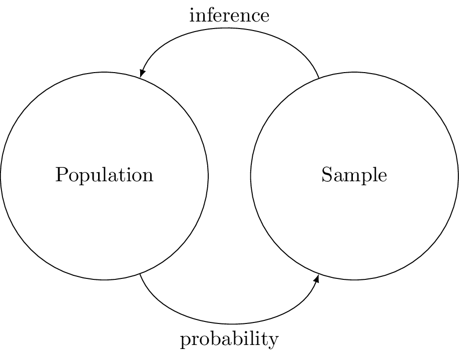

- With *point estimates*, we get the estimate that is correct on average.
- An even more useful quantity can be a range of plausible values for an estimate.
- Confidence interval is a way to construct an interval that will contain the *true value* in some fixed proportion of *repeated samples*.

## 2.2 Analytical Apporach

In the file `support.RData` you find the policy support measurements from the lecture. We want to calculate the 95% confidence interval for the mean.

First, we need to load the data. This time it’s easier because the data is in the `.RData` format, one of the native formats for R. Hence, no extra packages are required:

```r
load(file = here("raw-data/support.RData"))

# Let's have a look at the data first.

summary(support)
##    Min. 1st Qu.  Median    Mean 3rd Qu.    Max.
##   11.00   13.00   14.00   14.36   15.75   17.00

# summary() shows you the key measures of central tendency and variability.
```

### Base R

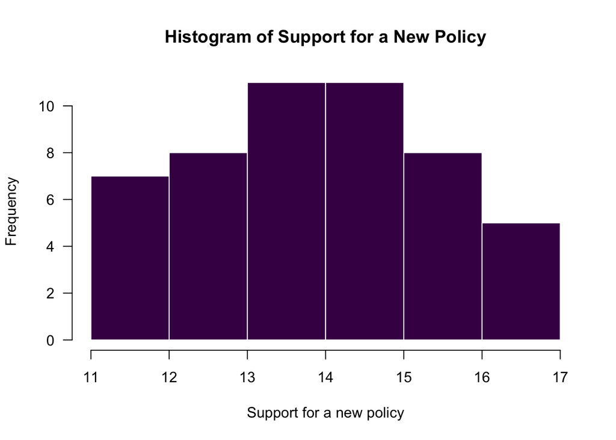

```r
# We should also have a look at the distribution, quick but ugly...
hist(support,
  main = "Histogram of Support for a New Policy",
  xlab = "Support for a new policy",
  col = viridis(1),
  border = F,
  las = 1
)
```

### ggplot2

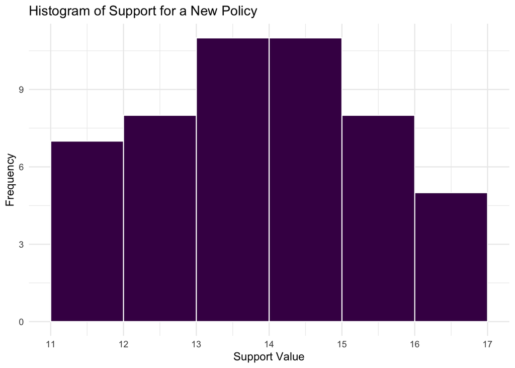

```r
ggplot() +
  geom_histogram(aes(x = support),
    boundary = 14,
    binwidth = 1,
    color = "white",
    fill = viridis(1)
  ) +
  labs(
    title = "Histogram of Support for a New Policy",
    x = "Support Value",
    y = "Frequency"
  ) +
  theme_minimal() +
  scale_x_continuous(breaks = c(seq(11, 17, by = 1)))
```

We can easily calculate the mean support for the new policy in our sample:

```r
mean(support)
## [1] 14.36
```

Since we only have a sample (i.e., the survey was only conducted once), we cannot confidently infer that the mean support in the population (unknown to us, $\theta$) is the same as in our sample (what we observed, $\hat{\theta}$). That’s why we may want to calculate the confidence intervals.

Let’s calculate the analytical 95% CI. We start by calculating the standard error of the estimate of the population mean:

$SE(\hat\theta) = \dfrac{\hat\sigma}{\sqrt{N}}$

$\hat\theta$ = Estimate of population mean

$\hat\sigma$ = Standard deviation of a sample

$N$ = Number of observations

```r
support_se <- sd(support) / sqrt(length(support))
support_se
## [1] 0.2281425
```

> How will the estimate $SE(\hat\theta)$ change if there were more data points (but standard deviation of the sample were the same)?

Now we can calculate the analytical 95% CI: $\hat\theta \pm 1.96 \times SE(\hat\theta)$

```r
ci_lo <- mean(support) + qnorm(0.025, 0, 1) * support_se # why use qnorm?
ci_up <- mean(support) + qnorm(0.975, 0, 1) * support_se
ci_an <- c(ci_lo, ci_up)

ci_an
## [1] 13.91285 14.80715
```

> What should we change to calculate the 99% confidence intervals? Will this 99% interval be larger or smaller than 95% CI?

*Tip: you can comment and un-comment multiple lines with `Ctrl + Shift + C` /`Cmd + Shift + C`.*

```r
# modify the following line to get 99% CIs
# mean(support) + qnorm(c(0.005, 0.995), 0, 1) * support_se
```

### 2.2.1 Understanding Confidence Intervals

In the lecture, you have seen a [simulation for the concept of confidence intervals](https://rpsychologist.com/d3/ci/). Let’s try to make one ourselves to better grasp the idea behind the interpretation of confidence intervals.

First, we’ll need to decide on the *true* population parameters. We will never know true population parameters in real life, but for the sake of demonstration, let’s do this.

```r
# create a population
true_mean <- 500
pop <- rnorm(10000, true_mean, 100)
```

Now we need to do the sampling part, like we would be doing in real life. We will take a subset of the population and estimate statistics based on that sample. But unlike in real life, we will take samples many times, say 100.

```r
n_iter <- 100 # we will take 100 samples (but only one in real life)
estimates <- NULL # empty object for estimates
confis <- matrix(rep(NA, n_iter * 2), # empty matrix for CIs
  ncol = 2, # for lower and upper CIs
  nrow = n_iter
)

for (i in seq_len(n_iter)) { # for the length of n_iter do:
  pop_sample <- sample(x = pop, size = 100) # take a sample of 100
  estimates[i] <- mean(pop_sample) # store its mean
  se <- sd(pop_sample) / sqrt(length(pop_sample)) # store SE for the sample
  confis[i, ] <- mean(pop_sample) + qnorm(c(0.025, 0.975)) * se # store 95% CIs
}

head(estimates)
```

```
## [1] 499.1148 497.7561 495.2273 506.1411 514.1443 501.4043
```

```r
head(confis)
```

```
##          [,1]     [,2]
## [1,] 480.9031 517.3265
## [2,] 475.5951 519.9171
## [3,] 476.9869 513.4677
## [4,] 487.5249 524.7572
## [5,] 494.4228 533.8658
## [6,] 483.3199 519.4888
```

#### Base R

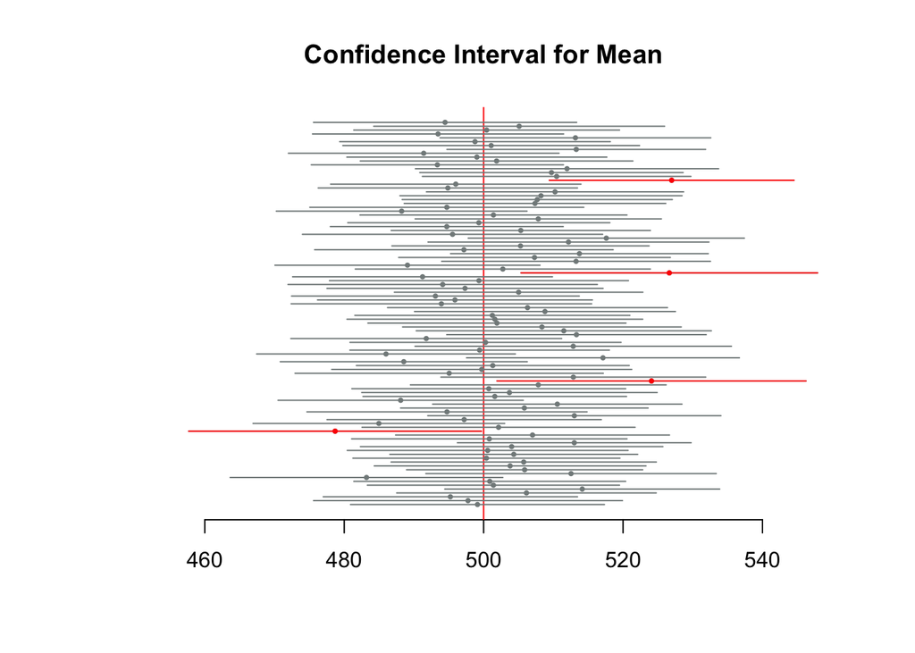

```r
plot(
  confis,
  xlim = c(450, 550),
  ylim = c(1, 100),
  type = "n",
  xlab = "",
  ylab = "",
  yaxt = "n",
  bty = "n",
  main = "Confidence Interval for Mean"
)

# Let's add our true parameter
abline(v = true_mean, col = "red")

for (i in seq_len(n_iter)) {
  segments(confis[i, 1], i, confis[i, 2], i, col = "azure4")
  points(estimates[i],
    i,
    pch = 19,
    cex = 0.4,
    col = "azure4"
  )
  # if lower CI is larger than 10 or upper CI smaller than 10
  if (confis[i, 1] > true_mean | confis[i, 2] < true_mean) {
    # paint red horizontal lines (since y0 == y1)
    segments(
      x0 = confis[i, 1],
      y0 = i,
      x1 = confis[i, 2],
      y1 = i,
      col = "red"
    )
    # add red points
    points(estimates[i],
      i,
      pch = 19,
      cex = 0.4,
      col = "red"
    )
  }
}
```

#### ggplot2

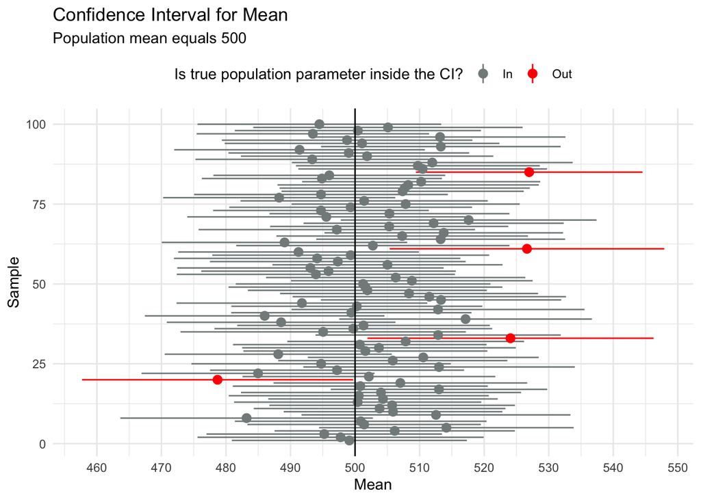

```r
# create a dataset from plotting from existing objects
CIs_data <- data.frame(
  mean = estimates,
  confis,
  n = 1:n_iter
)

# add a column for color
# if lower CI > true_mean or upper CI < true_mean, CI missed the true value and
# is coded as "out"
# ifelse(condition, value-if-true, value-if-false)
CIs_data$missed <- ifelse(CIs_data$X1 > true_mean | CIs_data$X2 < true_mean, "Out", "In")

ggplot(data = CIs_data) +
  geom_pointrange(
    aes(
      x = mean, # point value
      xmin = X1, # lower CI
      xmax = X2, # upper CI
      y = n, # y axis - just observation number
      color = missed
    ) # color varies by missed variable
  ) +
  geom_vline(
    aes(xintercept = true_mean), # add vertical line at true_mean
  ) +
  scale_color_manual(values = c("azure4", "red")) + # set our preferred colors
  theme_minimal() + # some theme to change the appearance
  labs(
    title = "Confidence Interval for Mean",
    subtitle = "Population mean equals 500",
    x = "Mean",
    y = "Sample",
    color = "Is true population parameter inside the CI?"
  ) +
  theme(legend.position = "top") + # switch the legend to the top
  scale_x_continuous(breaks = c(seq(450, 550, by = 10))) # change values on x-axis
```

## 2.3 Simulation Approach

Now we turn to the simulation approach. Here we simulate the sampling distribution of the statistic we are interested in and take the empirical quantiles from this simulated distribution.

The central limit theorem tells us that the *sampling distribution is normally distributed*. We assume that the sample mean is the population mean. The standard error is the standard deviation of this distribution.

First, let’s set the number of simulations to 1000.

```r
nsim <- 1000
```

Now let’s take random draws from a distribution with assumed parameters.

```r
simsupport <- rnorm(n = nsim,
                    mean = mean(support),
                    sd = support_se)
```

And now we are plotting the resulting distribution:

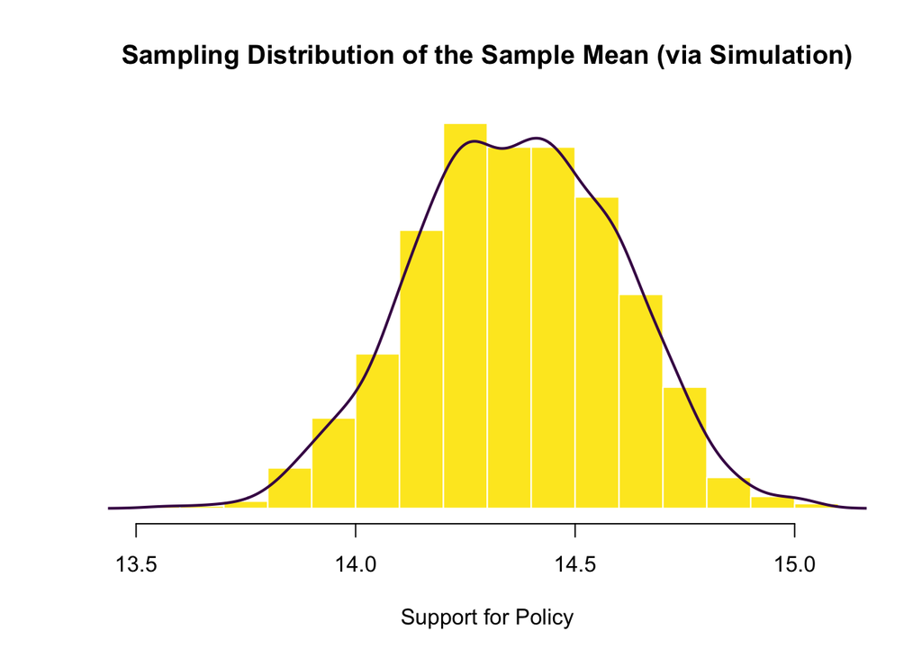

```r
hist(
  x = simsupport,
  main = "Sampling Distribution of the Sample Mean (via Simulation)",
  xlab = "Support for Policy",
  las = 1,
  col = viridis(2)[2],
  border = F, # remove the border
  breaks = 20,
  freq = FALSE,
  yaxt = "n",
  ylab = ""
)

# Now we will add some extras to the plot:
# Lines for density.

lines(density(simsupport),
  col = viridis(2)[1],
  lwd = 2
)
```

Now we can calculate empirical quantiles from the distribution:

```r
ci_sim <- quantile(x = simsupport,
                   probs =  c(0.025, 0.975))

ci_sim
##     2.5%    97.5%
## 13.91269 14.78863
```

And let’s see if there is a numerical difference between two approaches:

```r
ci_sim - ci_an # should be close to zero!
##          2.5%         97.5%
## -0.0001579264 -0.0185211296
```

Even better, we can even add the quantiles to the plot.

### Base R

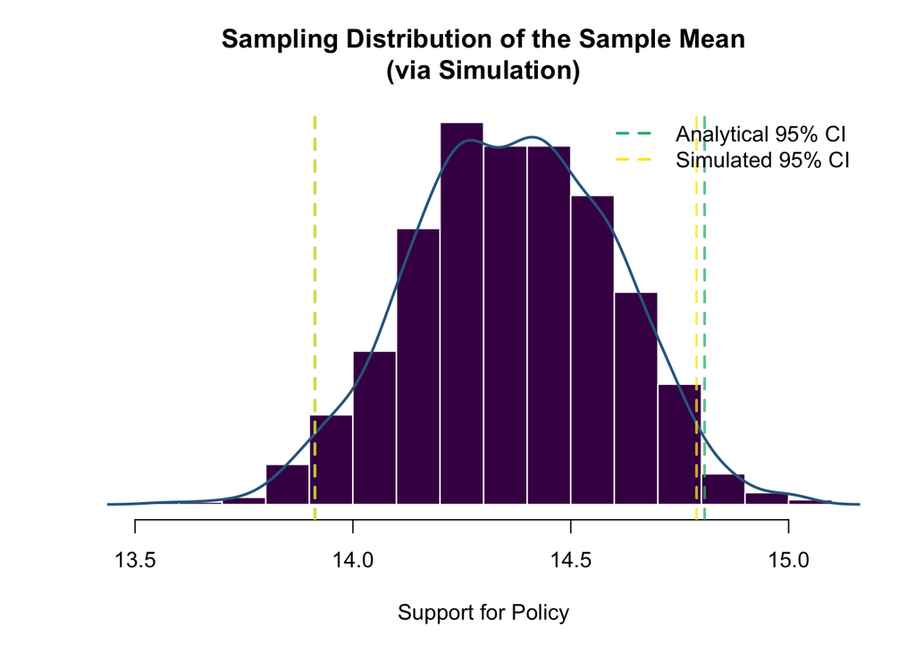

```r
# This is the plot from above.
hist(simsupport,
  las = 1,
  breaks = 20,
  freq = FALSE,
  main = "Sampling Distribution of the Sample Mean\n(via Simulation)",
  xlab = "Support for Policy",
  col = viridis(4)[1],
  border = F,
  yaxt = "n",
  ylab = ""
)


# Now we will add some extras to the plot:
# Lines for density.

lines(density(simsupport),
  col = viridis(4)[2],
  lwd = 2
)

# Let's add the analytical CI
abline(
  v = ci_an,
  col = viridis(4, alpha = 0.75)[3],
  lwd = 2,
  lty = 2
)

# How does the simulated CI compare to the analytical one?
# Let's have a look at it in the same plot!
abline(
  v = ci_sim,
  col = viridis(4, alpha = 0.75)[4],
  lwd = 2,
  lty = 2
)

# And let's add a legend
legend("topright",
  bty = "n",
  col = viridis(4)[3:4],
  lwd = 2,
  lty = 2,
  legend = c(
    "Analytical 95% CI",
    "Simulated 95% CI"
  )
)
```

### ggplot2

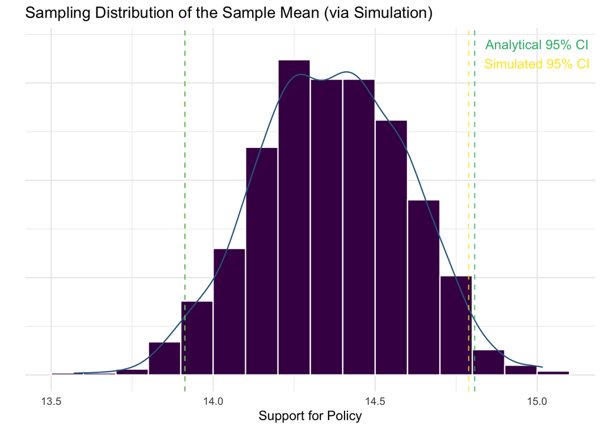

```r
# create a dataset
simsupport_df <- data.frame(simsupport)

ggplot(
  simsupport_df, # use our dataset
  aes(x = simsupport)
) + # put simsupport on x-axis
  labs(
    title = "Sampling Distribution of the Sample Mean (via Simulation)",
    x = "Support for Policy",
    y = ""
  ) +
  geom_histogram(aes(y = ..density..), # add histogram
    boundary = 14,
    binwidth = 0.1,
    fill = viridis(4)[1], # change color
    color = "white"
  ) + # make white bin borders
  geom_density(color = viridis(4)[2]) + # add density
  geom_vline( # add simulated CIs
    xintercept = ci_sim,
    color = viridis(4, alpha = 0.75)[4],
    linetype = "dashed"
  ) +
  geom_vline( # add analytical CIs
    xintercept = ci_an,
    color = viridis(4, alpha = 0.75)[3],
    linetype = "dashed"
  ) +
  theme_minimal() + # change appearance
  annotate("text", # add CIs label
    x = 15, # where to place label on x axis
    y = 1.7, # where to place label on y axis
    label = "Analytical 95% CI",
    color = viridis(4)[3]
  ) +
  annotate("text",
    x = 15,
    y = 1.6,
    label = "Simulated 95% CI",
    color = viridis(4)[4]
  ) +
  theme(
    axis.text.y = element_blank(),
    axis.ticks.y = element_blank()
  )
```

## 2.4 Bootstrapping Approach

[figure not shown]

> If we treat our sample as population, how do we achieve sampling variability with bootstrapping?

To remind you, here is what we need to do when using bootstrapping to generate confidence intervals:

1. Take a bootstrap sample - a random sample taken *with replacement* from the original sample, of the same size as the original sample
2. Calculate the bootstrap statistic - a statistic such as mean, median, proportion, etc. computed on the bootstrap samples
3. Repeat steps (1) and (2) many times to create a bootstrap distribution - a distribution of bootstrap statistics
4. Calculate the bounds of the XX% confidence interval as the middle XX% of the bootstrap distribution

Let’s see how we do this in R.

First, we need an empty vector for samples. This is good practice when using a loop, to make the process faster.

```r
bootmeans <- rep(NA, 1000) # repeat "NA" 1000 times, store in object "bootmeans"
```

Let’s loop over the mean from random samples *with replacement* from the support dataset.

> Does anyone remember what a `for` loop does?

```r
for (i in seq_len(1000)) {
  bootmeans[i] <- mean(sample(
    x = support,
    size = length(support),
    replace = TRUE # why?
  ))
}
```

Let’s have a look at the results:

### Base R

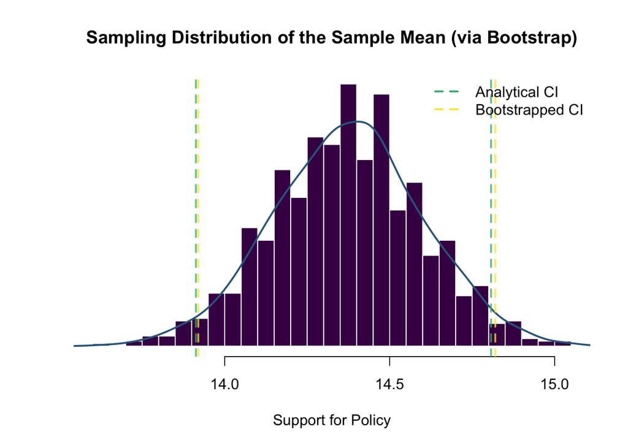

```r
hist(bootmeans,
  las = 1,
  breaks = 20,
  freq = FALSE,
  main = "Sampling Distribution of the Sample Mean (via Bootstrap)",
  xlab = "Support for Policy",
  col = viridis(4)[1],
  border = F,
  yaxt = "n",
  ylab = ""
)

# And we add the density curve again.

lines(density(bootmeans),
  col = viridis(4)[2],
  lwd = 2
)

# calculate empirical quantiles from your distribution

ci_boot <- quantile(bootmeans, p = c(0.025, 0.975))

# As above we can plot the CI.
abline(
  v = ci_boot,
  col = viridis(4, alpha = 0.75)[4],
  lwd = 2,
  lty = 2
)

# And we compare it to the analytical solution.
abline(
  v = ci_an,
  col = viridis(4, alpha = 0.75)[3],
  lwd = 2,
  lty = 2
)

# And the legend
legend("topright",
  bty = "n",
  col = viridis(4)[3:4],
  lwd = 2,
  lty = 2,
  legend = c(
    "Analytical CI",
    "Bootstrapped CI"
  )
)
```

### ggplot2

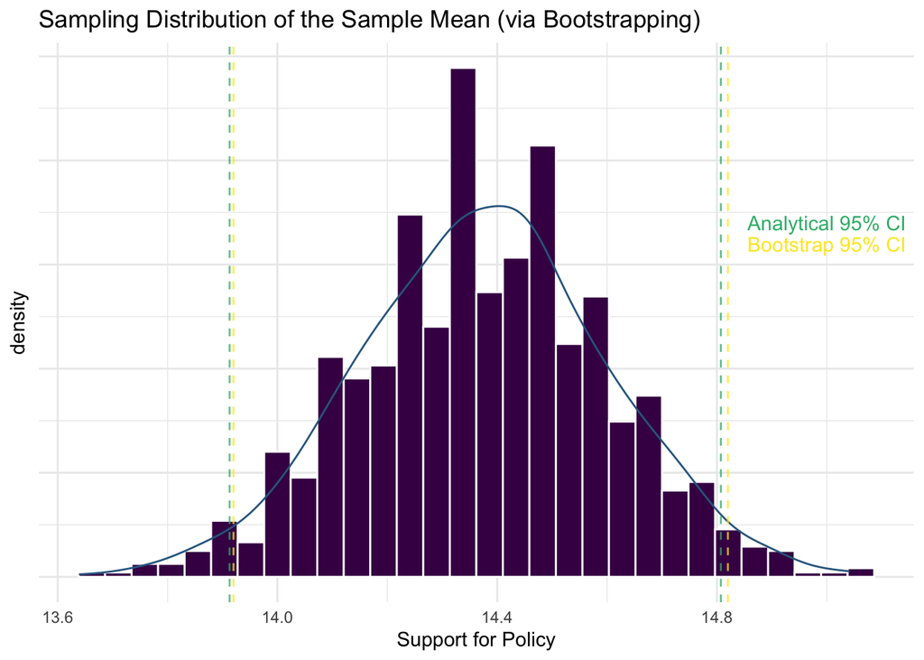

```r
bootmeans_df <- data.frame(bootmeans)
ci_boot <- quantile(bootmeans, p = c(0.025, 0.975))

ggplot(
  bootmeans_df,
  aes(x = bootmeans)
) +
  labs(
    title = "Sampling Distribution of the Sample Mean (via Bootstrapping)",
    x = "Support for Policy"
  ) +
  geom_histogram(aes(y = ..density..),
    fill = viridis(4)[1],
    color = "white"
  ) +
  geom_density(color = viridis(4)[2]) +
  theme_minimal() +
  geom_vline(
    xintercept = ci_an,
    color = viridis(4, alpha = 0.75)[3],
    linetype = "dashed"
  ) +
  annotate("text",
    x = 15,
    y = 1.7,
    label = "Analytical 95% CI",
    color = viridis(4)[3]
  ) +
  geom_vline(
    xintercept = ci_boot,
    color = viridis(4, alpha = 0.75)[4],
    linetype = "dashed"
  ) +
  annotate("text",
    x = 15,
    y = 1.6,
    label = "Bootstrap 95% CI",
    color = viridis(4)[4]
  ) +
  theme(
    axis.text.y = element_blank(),
    axis.ticks.y = element_blank()
  )
## `stat_bin()` using `bins = 30`. Pick better value with `binwidth`.
```

We can also see that the difference between analytical and bootstrap CIs is rather small:

```r
ci_boot - ci_an
##        2.5%       97.5%
## 0.007150994 0.012849006
```

# 3 Beyond Basic Quantities of Interest

What’s the point about the simulation and bootstrap approach if we are able to derive CIs analytically? The next example shows that for some quantities of interest, CIs are not easy to derive analytically, but the simulation and bootstrap approaches work just as before.

## 3.1 Example: Left-Voting Ratios

In a sample of size 1000 (500 men and 500 women), 55% of men and 65% of women vote left. Calculate the confidence interval for the “left-voting” ratio of men to women using the simulation approach. This is an example from the lecture slides 20-21.

With simulation approach, we need some values to set up the distribution, so mean and standard error for the Normal distribution, and then we will take draws from a distribution with such parameters.

The ratio is $\dfrac{0.55}{0.65}$.

The formula for the standard error for proportions:

$SE(\hat p) = \sqrt{\dfrac{\hat p (1-\hat p)}{n}}$

Let’s translate it all into R:

```r
p_hat_men <- 0.55
p_hat_women <- 0.65

n_men <- 500
n_women <- 500

# Calculate the standard errors: sqrt(p * (1 - p) / n)

se_men <- sqrt(p_hat_men * (1 - p_hat_men) / n_men)
se_women <- sqrt(p_hat_women * (1 - p_hat_women) / n_women)


# Draw a sample
nsim <- 1000

p_men <- rnorm(nsim, p_hat_men, se_men)
p_women <- rnorm(nsim, p_hat_women, se_women)

# Calculate the ratios from the simulated vectors

ratio <- p_men / p_women

# Finally, provide CI via simulation
ci_sim <- quantile(ratio, c(0.025, 0.975))

ci_sim
##      2.5%     97.5%
## 0.7584321 0.9380915
```

## 3.2 Exercise: Difference in Means

Our previous quantity of interest was the “left-voting” ratio of men to women. Now we are interested in calculating a difference in means. Let’s work with another substantive example here.

The file `polity.dta` contains information on Polity scores, a measure of democracy in the country, which varies from 0 to 10, with 0 being the least democratic. We want to test if the difference in polity scores between *Eastern Europe* and *Western Europe and North America* is “statistically significant”.

Let’s load the dataset:

```r
data <- read.dta("raw-data/polity.dta")  # Why doesn't load("polity.dta") work?
```

First, we always investigate the dataset:

```r
head(data)
```

```
##   ht_region ccode      cname fh_polity2         region
## 1         1   100   Bulgaria   9.333334 Eastern Europe
## 2         1   268    Georgia   6.250000 Eastern Europe
## 3         1   804    Ukraine   6.500000 Eastern Europe
## 4         1   112    Belarus   1.583333 Eastern Europe
## 5         1   705   Slovenia  10.000000 Eastern Europe
## 6         1    31 Azerbaijan   2.000000 Eastern Europe
```

```r
glimpse(data) # function from dplyr package
```

```
## Rows: 159
## Columns: 5
## $ ht_region  <dbl> 1, 1, 1, 1, 1, 1, 1, 1, 1, 1, 1, 1, 1, 1, 1, 1, 1, 1, 1, 1,…
## $ ccode      <fct> 100, 268, 804, 112, 705, 31, 440, 616, 233, 642, 643, 795, …
## $ cname      <fct> "Bulgaria", "Georgia", "Ukraine", "Belarus", "Slovenia", "A…
## $ fh_polity2 <dbl> 9.3333340, 6.2500000, 6.5000000, 1.5833333, 10.0000000, 2.0…
## $ region     <fct> Eastern Europe, Eastern Europe, Eastern Europe, Eastern Eur…
```

```r
table(data$region)
```

```
##
##          East Asia (including Japan & Mongolia)
##                                               6
##                                  Eastern Europe
##                                              26
##                                   Latin America
##                                              20
##                  North Africa & the Middle East
##                                              20
##                                      South Asia
##                                               7
##                                 South-East Asia
##                                               9
##                              Sub-Saharan Africa
##                                              45
##                                   The Caribbean
##                                               3
## The Pacific (excluding Australia & New Zeeland)
##                                               3
##                Western Europe and North America
##                                              20
```

We start by extracting Polity scores of *Eastern Europe* and *Western Europe and North America* from the data set. Remember selecting/subsetting?

```r
west <- data$fh_polity2[data$region == "Western Europe and North America"]
east <- data$fh_polity2[data$region == "Eastern Europe"]
```

### 3.2.1 Difference in Means via Simulation

In order to find out whether the difference in mean Polity scores between *Eastern Europe* and *Western Europe and North America”* is “statistically significant”, we need to derive confidence intervals of this difference.

#### 3.2.1.1 Calculate Standard Errors

To start, calculate the standard errors of the mean estimates of polity scores for *Eastern Europe* and *Western Europe and North America*.

Formula for standard errors: $SE(\hat\theta) = \dfrac{\hat\sigma}{\sqrt N}$

$\hat\theta$ = Estimate of population mean

$\hat\sigma$ = Standard deviation of a sample

$N$ = Number of observations

```r
# se_east <-
# se_west <-
```

#### 3.2.1.2 Simulate Confidence Intervals for the Means

We now have standard deviations for the mean polity scores of both regions. This equips us to simulate confidence intervals for these estimates.

```r
# # 1. Simulate sampling distributions
#
# nsim <-
# d_west <-
# d_east <-
#
# # 2. Calculate quantiles to get CI
#
# ci_west <-
# ci_east <-
```

#### 3.2.1.3 Simulate Confidence Intervals for the Difference in Means

Now we can check the difference: Subtract the simulated sampling distribution of the mean of western countries from the simulated sampling distribution of eastern countries and calculate the quantiles to get the CI of the difference in means. You can also plot the sampling distribution of the difference in means and calculate its mean.

```r
# # 1. Subtract the simulated sampling distributions of the mean (west-east)
#
# diff <-
#
# # 2. Calculate quantiles to get CI
#
# ci_sim <-
#
# # 3. plot and mean
#
# hist()
# mean()
```

### 3.2.2 Appendix 1: This is how we get this analytically

We do it by hand, using the normal approximation.

```r
n1 <- length(west)
n2 <- length(east)

ci_up <- (mean(west) - mean(east)) + 1.96 * sqrt(var(west) / n1 + var(east) / n2)
ci_low <- (mean(west) - mean(east)) - 1.96 * sqrt(var(west) / n1 + var(east) / n2)

ci_ahand <- c(ci_low, ci_up)
```

Of course there is also an easy way: in this case the t-test function.

```r
t.test(west, east)
##
##  Welch Two Sample t-test
##
## data:  west and east
## t = 5.4398, df = 25.073, p-value = 1.189e-05
## alternative hypothesis: true difference in means is not equal to 0
## 95 percent confidence interval:
##  2.100570 4.659686
## sample estimates:
## mean of x mean of y
##  9.966667  6.586539

ci_t <- t.test(west, east)[[4]][1:2]
```

### 3.2.3 Appendix 2: This is how we get this via bootstrap

We again need an empty vector to save the results.

```r
diff_boot <- rep(NA, 1000)

for (i in seq_len(1000)) {
  a <- mean(sample(west, length(west), replace = T))
  b <- mean(sample(east, length(east), replace = T))

  diff_boot[i] <- a - b
}

mean(diff_boot)
## [1] 3.361145
ci_boot <- quantile(diff_boot, c(0.025, 0.975))

# Finally, we present the results in a table.
res <- matrix(NA, 4, 2)

res[1, ] <- ci_sim
res[2, ] <- ci_ahand
res[3, ] <- ci_t
res[4, ] <- ci_boot

rownames(res) <- c("Simulation", "By hand", "t-test", "Bootstrapping")
colnames(res) <- c("Lower 95% bound", "Upper 95% bound")
res
##               Lower 95% bound Upper 95% bound
## Simulation          0.7584321       0.9380915
## By hand             2.1622324       4.5980239
## t-test              2.1005704       4.6596858
## Bootstrapping       2.2004325       4.5324518
```

> Pro-tip: Use `knitr::kable()` to get nicely formatted tables from R objects to Markdown

```r
knitr::kable(res,
  digits = 3
)
```

|  | Lower 95% bound | Upper 95% bound |
| --- | --- | --- |
| Simulation | 0.758 | 0.938 |
| By hand | 2.162 | 4.598 |
| t-test | 2.101 | 4.660 |
| Bootstrapping | 2.200 | 4.532 |

# 4 Concluding remarks

You learned about the different ways to calculate confidence intervals in R, with simulation and bootstrapping as well as analytically. You may still wonder which confidence level is the most appropriate to use. There is always a trade-off between precision and accuracy of the statements when it comes to reporting the quantities of interest. If we want to be very certain that we capture the population parameter, we may be tempted to use a wider confidence interval. This, however, comes with certain drawbacks, such as the interval becoming rather uninformative:

[figure not shown]

The best solution to get the best of both worlds - high accuracy as well as high precision - would be to increase the sample size, which is often easier said than done.

In your homework you will:

- Calculate some CIs using different approaches.
- See how smart students in Mannheim are.
- And check whether there was foul play in an election.